# EDAV-CC24

Bangwei Zhou, Zhihao Ai

# 第3章 调查连续变量

## 3.2 连续变量可能具有哪些特征？

可能有

**不对称性** 分布可能偏向左或右，例如收入的分布。

**离群值** 有一个或多个与远离其余数据的值。

**多峰性** 分布具有一个以上的峰，例如，老忠实间歇泉数据中的两个变量。

**空缺** 在某些值的范围内，数据中没有任何符合的个体。这在考试成绩的数据中可能发生，即没有任何低于及格线的分数。

**堆积** 一些值过于经常地出现。出生体重是一个很好的例子[Clemons and Pagano，1999]。也许除了精确到克或盎司地称重新生儿，还有更重要的事……

**舍入** 数据中仅有某些值（像整数），比如年龄的分布。

**不可能值** 超出合理范围的值，例如年龄为负数。在UCI机器学习库的某一版本的皮马印第安人数据集[Bache and Lichman，2013]中，存在血压为零和皮肤厚度为零的情况。

**错误值** 由于某种原因看上去有问题的值。在一个德国汽车保险数据集中，有一些驾驶员的出生年份表明他们小于16岁，因此他们无法获得驾照。这也是有可能的，因为为从未开车的人提供保险，将为他们建立几年没有索赔的历史！

图形很适合展示构成数据分布形状的特征。相较于一组概括的统计量，他们可以提供更多和不同的信息。显然，最好同时使用这两种方法。

对于单个变量，均值通常是最重要的统计量。T检验可能是最常用的用于检验均值的统计检验。如果数据来自正态分布，可以使用T检验。对于来自正态分布的小型数据集（T检验是特意为小样本设计的），数据可能看上去很不正态，这就是为什么正态性检验对T检验的效用和支持都很有限。幸运的是，T检验对于非正态性非常稳定。不过我们还是至少应该在进行分析前，检查数据是否有严重的非正态性。而用图形是最好的方法。

## 3.3 寻找特征

本节将主要使用直方图讨论不同的数据集，以展示可能存在的特征以及如何找到它们。无论您偏好哪种图，研究很多示例以了解可能出现的各种类型以及如何去解释它们是尤为重要的。

**Galton的身高数据**

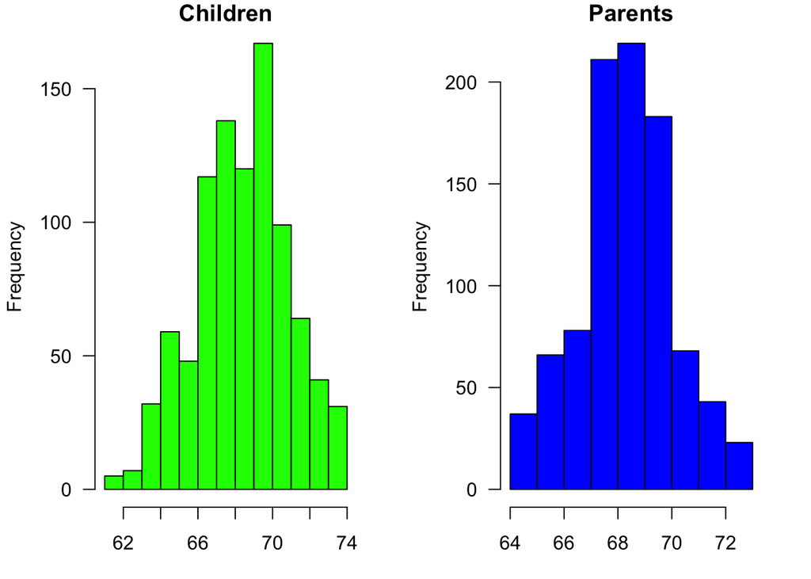

图3.2：子女和父母平均身高的直方图，使用默认组距。因为是分别绘制的，所以尺度不同。两个分布大致是对称的，子女的更为分散。组距设为1英寸。如果数据以厘米为单位，2.5厘米的组距可能更合适。

```r
data(galton, package="UsingR")
ht <- "height (in)"
par(mfrow=c(1,2), las=1, mar=c(3.1, 4.1, 1.1, 2.1))
with(galton, {
  hist(child, xlab=ht, main="Children", col="green")
  hist(parent, xlab=ht, main="Parents", col="blue")})
```

Galton使用了包括父母和子女的身高数据，建立了他著名的关于相关和回归的思想。在**UsingR**包中的数据集*galton*包含了928个子女身高和205个”中间父母“身高。每个”中间父母“身高是父亲身高和1.08倍母亲身高的中间值。女儿的身高也都被乘以1.08。值得注意的是，此数据集中，对于每个子女身高，都有一个”中间父母“身高与其对应，因此许多”中间父母“身高是重复的。（有兴趣研究包含完整家庭信息（包括孩子的性别和顺序）的数据集的读者，请参阅[Hanley,2004]以及作者的网页）图3.2展示了两个变量的默认设置下的直方图。

两种分布都大致对称，并且似乎没有异常值。由于两个图的尺度不同，很难直接比较。尽管它们似乎具有不同的组距，但实际上是相同的，这要归功于R能够寻找合理的间隔（在此情况下是整数），并且仅绘制数据范围的组。使组距非常小可以很好地帮助寻找空缺或堆积。条形图也能够做到，但不适用于具有许多不同值的大数据集。点图可以很好地发现空缺，但不能发现堆积。

图3.3中，在组距为0.1的直方图中，我们可以看到身高的取值只有有限的一些（如果查阅此版本的数据集的R帮助，您会发现这些数据源自一个表格，所以单个值是没有被提供的）。在两个直方图中，似乎都在临界边界值的地方空缺较小。绘制出“原始”数据证实了这点，并且可以发现，父母的身高几乎都以.5结尾，而子女的身高几乎都以.2结尾。使用Hanley版本的数据集会更好。图3.3使用了`truehist`函数，因为可以直接设置组距。（`hist`使用组数。）由于它将直方图视为密度的估计，*y*轴尺度不再显示频率。

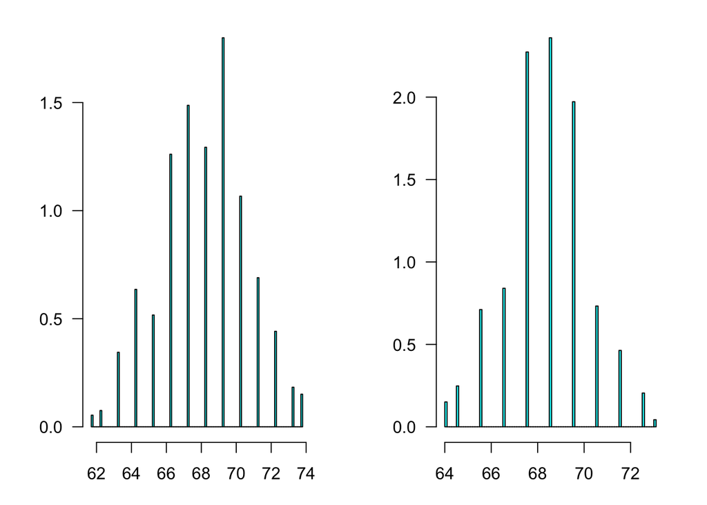

图3.3：使用小组距绘制的子女和中间父母身高的直方图，以展示身高取值实际很少。显然，数据是汇总过的或记录时精度有限。因分别绘制，两图的尺度有所不同。

```r
par(mfrow=c(1,2), las=1, mar=c(3.1, 4.1, 1.1, 2.1))
with(galton, {
  MASS::truehist(child, h=0.1)
  MASS::truehist(parent, h=0.1)})
```

实际上为了比较分布，可以绘制很多种图，例如平行箱形图。图3.4展示了具有相等的尺度和组距的上下两个直方图。*x*轴的极限包括了整个数据范围，*y*轴极限为则通过观察选择。

正如Hanley所指出的那样，在解释数据时应牢记，Galton“通过提供奖品”获得了“他们自己的家庭记录的最好摘要”[Hanley，2004年]，因此样本几乎不随机；数据已经被四舍五入以用于制表；家庭成员数量从1到15，因此在数据集中一个中间父母数据出现了15次，而33个数据只出现一次。中位数已用红色垂直线标记。虽然均值十分接近，父母的分布明显更为集中。这是因为每个父母的值都是两个值的平均值。有趣（也许甚至可疑）的是子女的标准差2.52几乎恰好是$\sqrt{2}$乘以父母的标准差1.79。

您可能会认为，如果我们知道每个父母的身高值以及子女的性别，就像Hanley的网页中Galton的完整数据那样，那么身高分布将是清楚的双峰分布，一个是女性的峰，一个是男性的峰。但不是。身高分布极少如此，像[Schilling et al.，2002]中所讨论的，其中还包括一些很好的推定的双峰分布的照片样例，它们是由让人们根据自己的身高排队构成的。

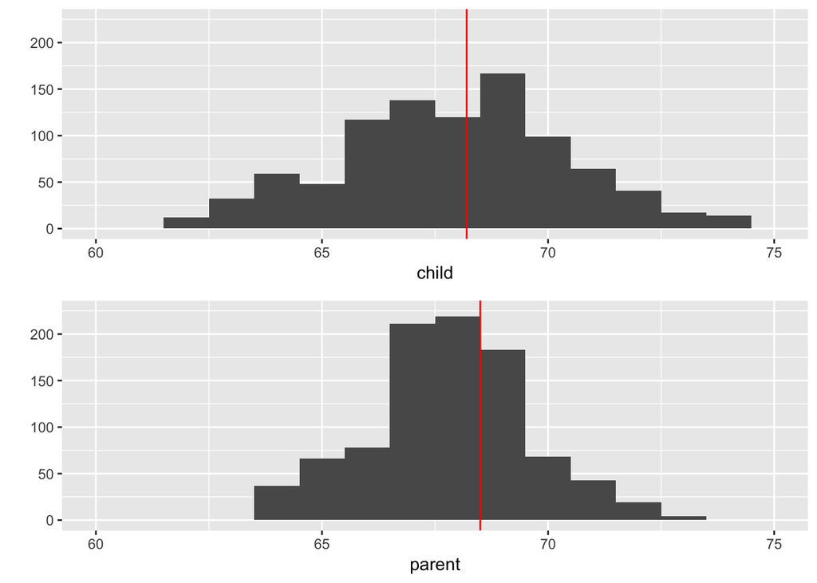

图3.4：在相同尺度下的子女和中间父母身高的直方图，中位数用红色标记。父母的身高分布变化较小，中位数稍高一些。

```r
c1 <- ggplot(galton, aes(child)) + geom_bar(binwidth=1) +
  xlim(60, 75) + ylim(0, 225) + ylab("") +
  geom_vline(xintercept=median(galton$child), col="red")
p1 <- ggplot(galton, aes(parent)) + geom_bar(binwidth=1) +
  xlim(60, 75) + ylim(0, 225) + ylab("") +
  geom_vline(xintercept=median(galton$parent), col="red")
grid.arrange(c1, p1)
```

## 3.5 哪些图可以展示单个连续变量？

可以选用以下类型的图来展示连续的数据

**直方图** 将数据分为多个区间，为每个区间绘制一个条形图，展示经验分布。

**箱形图** 显示单个异常值和一些可靠的统计量，对于找出异常值和 比较各子组的分布很有帮助。

**点图** 将每个点分别绘制为一个点，非常适合于发现数据中的空缺。

**轴须图** 将每个点分别绘制为一条线，通常附加在另一个图的水平轴上。

**密度估计** 绘制变量分布的估计密度，因此更像模型而不是数据展示。

**分布估计** 显示估计的分布函数，如果一个分布总是在另一个分布的“前面”，则很适于比较这两个分布。

**分位图** 比较分布与理论分布（通常是正态分布）

还有其他可能性（例如，次数多边图，P-P图，平均偏移直方图，Shorth图，豆荚图）

R的`plot`默认绘制变量与个体索引的散点图。这可能会有用（例如，显示数据是否已按升序排序或前几个值或最后几个值与其他值不同），但一般没用。不同的分析师可能偏爱不同的图，例如我喜欢直方图和箱形图。明显的特征大概率在所有图中都可以被发现。

为了发现微妙的现象，探索性分析的最佳方法是绘制多种图。有一些一般性建议可以遵循，例如对于小型数据集，直方图效果不佳，对于大型数据集，点图效果不佳，对于多峰性，箱行图效果不佳，但一些明显不适当的图经常可以令人惊讶地展现一些信息。最重要的建议还是绘制多种图。

如果数据高度不对称，考虑某些变换通常是明智，比如使用Box-Cox变换。图形显示可以帮助您评估任何变换的有效性，但他们无法告诉您是否这是否合理。您应该同时考虑如何解释转换后的变量及它的统计属性。

## 3.6 绘图选项

- *直方图的组距（和锚点）*

有一些有趣而令人印象深刻的关于使用数据决定组距的文献。[Scott，1992]和Wand的文章（例如，[Wand，1997]）是可靠的来源。实际上，通常有很好的理由去选择在不是数学意义上最佳的特定组距。数据可能是以年为单位的年龄，以分钟为单位的时间或以英里为单位的距离。用一个非整数组距在数学上可能令人满意，但也可以隐藏有用的经验信息。重要的是要记住，直方图是用来展示数据的；它们并不适用于密度估计。有更好的方法估计生成数据的可能密度。要牢记的是，决定最佳直方图组距的方法会假设一个给定的锚点，比如第一个组的起点。这两个参数都应该用来优化。在他的**ggplot2**包中，Wickham并未尝试寻找任何”最佳“选择，而是使用30个组并显示一条说明如何更改组距的消息。这是实际的解决方案。

- *不等组距*

一些作者在介绍直方图时会指出可以使用不等的组距。虽然这个想法理论上很有吸引力，但在实际中应用很尴尬因为难以解释。如果你仍然想要这么做，请考虑变换变量。

- *密度估计的带宽*

组距对于直方图至关重要，而带宽对于密度估计至关重要。有很多R包提供不同的带宽公式，但很难说哪个值得推荐。尝试一些带宽会更有效。由于您可以在一个图上叠加多个密度估计，比较它们会很容易，只需使用不同的颜色使其突出即可。

- *箱形图*

Tukey对箱形图的定义区分了异常值（距离箱形超过1.5倍箱长度）和极端离群值（距离箱形超过3倍箱长度），而许多箱形图并不显示这个区别。其实令人沮丧的，存在许多不同的箱形图定义，因此您应该始终确认是哪一种被使用了。有些不标记离群值，有些使用标准差而不是可靠的统计量，存在各种各样的变化。

同一窗口中的一组箱形图可以是同一变量的箱形图，每个子组一个，或不同变量的箱形图。有必要知道是哪种类型。分组的箱线图必须具有相同的尺度，并且其宽度是关于组大小的方程。不同变量的箱形图可能具有不同的尺度，每个个体出现在每个箱形图中（除了缺失值），因此无需考虑不同的宽度。

## 3.7 连续变量的建模和检验

1. 均值

连续数据最常见的检验是通过某种方式检验均值，可能是相对于一个标准值，或与其他变量的均值相比较，或用子集。通常使用T检验。因为涉及该主题的文章太多，在此选择某一个参考是不公平的。另外，也可以检验中位数，特别是结合箱形图时。

2. 对称性

[Zheng and Gastwirth，2010]讨论了若干关于未知中位数的对称性检验，并提出自助抽样以提高检验的功效。

3. 正态性

有许多正态性测试（例如，Anderson-Darling，Shapiro-Wilk， Kolmogorov-Smirnov）。它们对小样本效果不好，对于特别大的样本又太过强烈。大样本往往具有某些特征导致零假设被拒绝。有一本书关于正态性检验[Thode Jr.，2002]，也有一个R包**nortest**提供了五种检验，加上R自带的**stats**包中Shapiro-Wilk检验。检验评估是否存在某些偏离正态的证据，而图形（尤其是分位图）有助于识别偏离正态的程度和类型。

4. 密度估计

R中有很多包提供各种形式的密度估计，因为太多不便全部列出。它们求出密度估计，但并不检验。选择您认为不错的一个（或多个）并使用它（或它们）。请记住，具有严格边界的变量密度（例如，无负数值）需要在边界处进行特殊处理。至少一个R包，**logspline**，为此问题提供了一个选项。大多数没有这么做。

5. 离群值

关于离群值的经典书籍[Barnett and Lewis，1994]描述了许多对于离群值的检验，它们主要用于单变量分布和个案。他们有多有用可能取决于特定的应用情景。像书中建议的，您需要注意掩盖（一组异常值使您无法识别另一个）和淹没（误把标准观测结果作为异常值）。

6. 多峰性

Good和Gaskin为寻找众数在一篇经常被引用的文章中[Good and Gaskins，1980]引入了“碰撞狩猎”（Bump-Hunting）一词。用于检验单峰性的浸入检验（dip test）在[Hartigan and Hartigan，1985]中被提出，可在R包**diptest**中找到。

# 7 图表：小提琴图

## 7.1 本节介绍如何制作小提琴图。

## 7.2 R中的一些例子

我们调用`datasets`包中的`chickwts`，使用`ggplot2`绘制一副小提琴图。

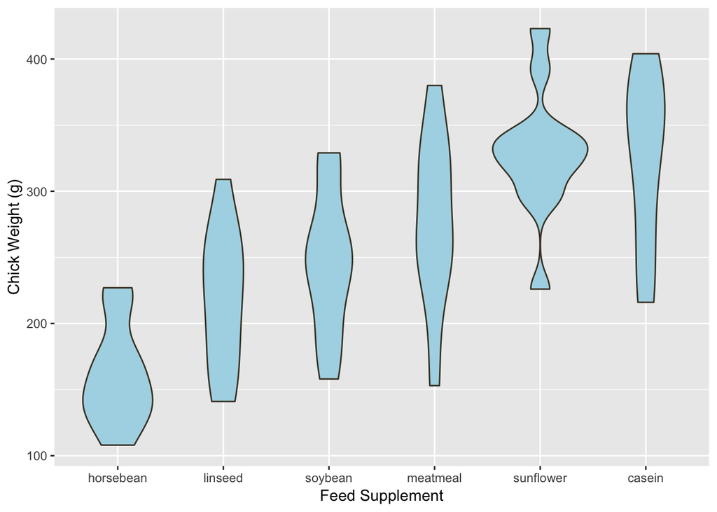

这是该代码:

```r
# import ggplot and the Datasets Package
library(datasets)
library(ggplot2)

supps <- c("horsebean", "linseed", "soybean", "meatmeal", "sunflower", "casein")

# plot data

ggplot(chickwts, aes(x = factor(feed, levels = supps),
                     y = weight)) +
  # plotting
  geom_violin(fill = "lightBlue", color = "#473e2c") +
  labs(x = "Feed Supplement", y = "Chick Weight (g)")
```

## 7.3 将统计量添加到小提琴图中

### 7.3.1 添加中位数和四分位距

我们可以将中位数和四分位距加到小提琴图上

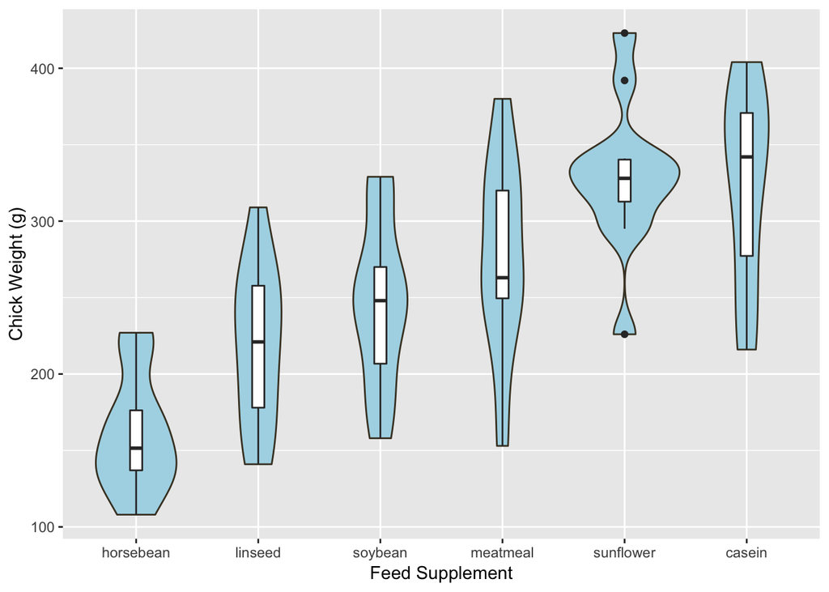

```r
ggplot(chickwts, aes(x = factor(feed, levels = supps),
                     y = weight)) +
  # plotting
  geom_violin(fill = "lightBlue", color = "#473e2c") +
  labs(x = "Feed Supplement", y = "Chick Weight (g)") +
   geom_boxplot(width=0.1)
```

我们只需添加一个箱形图即可。

### 7.3.2 数据显示为点

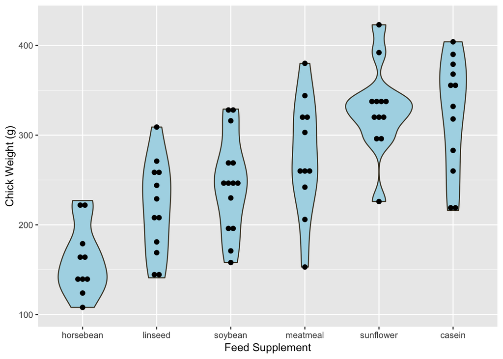

```r
ggplot(chickwts, aes(x = factor(feed, levels = supps),
                     y = weight)) +
  # plotting
  geom_violin(fill = "lightBlue", color = "#473e2c") +
  labs(x = "Feed Supplement", y = "Chick Weight (g)") +
  geom_dotplot(binaxis='y', dotsize=0.5, stackdir='center')
```

## 7.4 描述

小提琴图类似于箱形图。它较箱形图的优势在于，可以同时可视化数据的分布和概率密度。我们可以将小提琴图视为箱形图和核密度图的结合。

小提琴图可以让我们看到数据是单峰，双峰还是多峰。这些简单的细节无法在箱形图中看到。可以通过小提琴图的宽度看出分布。

## 7.5 何时使用

小提琴图仅应用于显示连续变量。

## 7.6 外部资源

[ggplot2小提琴图](http://www.sthda.com/english/wiki/ggplot2-violin-plot-quick-start-guide-r-software-and-data-visualization)：展示可以添加到小提琴图的各种自定义设置的资源。